# HRV analysis

## Data Aquisition

This document contains the analysis of the heart rate variabillity from an ECG recording of piglet number 2334. This recording was taken on the 8/11/2018 using the CFM data aquisition system from Inspiration technologies. The data was sampled at $256Hz$ with a high pass cutoff at 20Hz, and a 50Hz notch filter. R wave annotations were applied using a script written in MATLAB that uses the maximal overlap discrete wavelet transform $(MODWT)$ to enhance the R peaks in the ECG waveform. Then the r squared absolute value of the signal approximation built from the wavelet coefficients is used to employ the Signal Processing Toolbox peak finding algorithm to identify the R peaks. The beat positions in time were then saved as an American Standard Code for Information Interchange(ASCII) text file.

The Analysis pipeline will proceed as follows:

1.Preprocessing a. Creation of the HRV data structure and file loading b. Removal of outliers and ectopic beats c. Interpolation using cubic splines

2. Time-domain analysis
3. Frequency Domain analysis
1. Visualisation of the spectrogram and periodogram
2. Computation of the spectrogram using both Short Time Fourier Transform and Daubuchie wavelets
4. Nonlinear analysis
1. Hypothesis testing (various tests + surrogate data)
2. Phase space reconstruction
3. Denoising
4. Estimation of the correlation dimension
5. Estimation of the maximal Lyapunov exponent
6. Recurrence Quantification Analysis
7. Visualisation of the Poincare plot and elipse fitting
5. Fractal analysis
1. Estimation of the Hurst exponent via regression of the PSD slope
2. Detrended Fluctuation Analysis

## Build a non-interpolated HR data structure

The HRV data structure was created and the RR intervals were imported.

```
##
## waveslim: Wavelet Method for 1/2/3D Signals (version = 1.7.5.1)
```

```
##  Loading beats positions for record: 2334_RR_pre.txt
```

```
##  Path: S:/UQCCR-ColditzProjects/Bjorkman_other/Bjorkman_StemCell/SC_8_day/SC_Rwd/HRV_files/Analysis/source_data
```

```
##  Scale: 1
```

```
##  Date:  01 / 01 / 1900
##   Time:  00 : 00 : 00
```

```
##  Number of beats: 6281
```

```
##  Loading beats positions for record: 2334_RR_HI.txt
```

```
##  Path: S:/UQCCR-ColditzProjects/Bjorkman_other/Bjorkman_StemCell/SC_8_day/SC_Rwd/HRV_files/Analysis/source_data
```

```
##  Scale: 1
```

```
##  Date:  01 / 01 / 1900
##   Time:  00 : 00 : 00
```

```
##  Number of beats: 6734
```

```
##  Loading beats positions for record: 2334_RR_inf.txt
```

```
##  Path: S:/UQCCR-ColditzProjects/Bjorkman_other/Bjorkman_StemCell/SC_8_day/SC_Rwd/HRV_files/Analysis/source_data
```

```
##  Scale: 1
```

```
##  Date:  01 / 01 / 1900
##   Time:  00 : 00 : 00
```

```
##  Number of beats: 5448
```

## Filtering and interpolation of the HR file

The RHRV software package provides a GUI inerface for removing aritifacts and nonsensical beats.

In order to perform frequency and nonlinear analytical techniques a time series with uniformly distributed datapoints must be used, the process by which this is done is called interpolation. The most usual are linear or cubic splines interpolation. The sampling frequency to obtain the equally spaced heart rate signal has to be set in both; the default value in the RHRV package is 4 Hz, ideal for adult human signals; 8Hz has been chosen for neonatal piglets, given that the HR of the neonatal pig is appproximatly double a human adult HR. The outcome of this step yields, a new heart rate signal that is adequate for performing spectral analysis, as well as time and nonlinear analysis.

```
##  Plotting non-interpolated instantaneous heart rate
```

```
##  Number of points: 6278
```

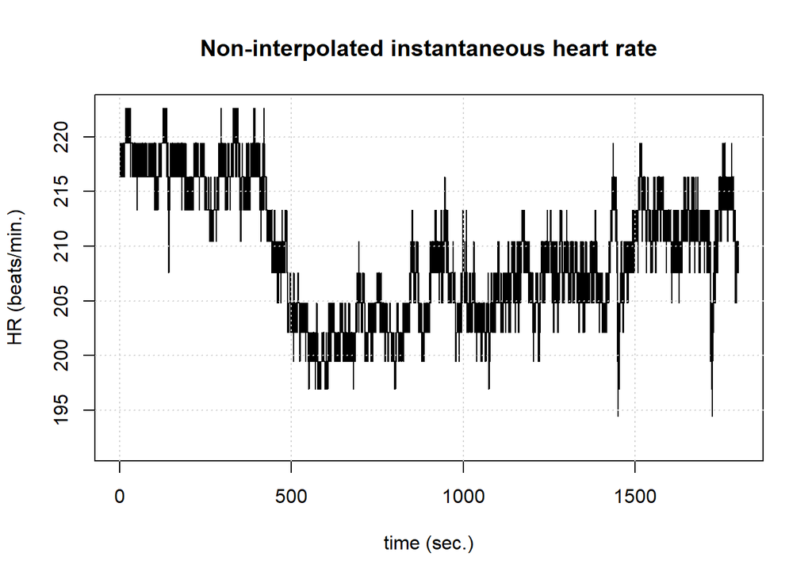

```r
#Visualise final output
PlotNIHR(hrv.data.pre)
```

```
##  Plotting non-interpolated instantaneous heart rate
```

```
##  Number of points: 6732
```

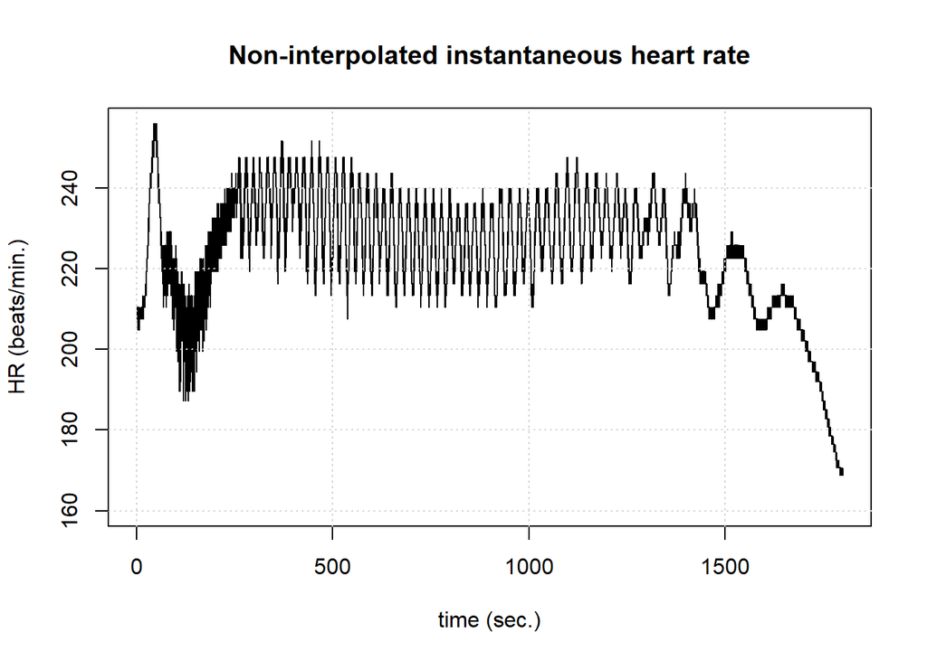

```r
PlotNIHR(hrv.data.HI)
```

```
##  Plotting non-interpolated instantaneous heart rate
```

```
##  Number of points: 5422
```

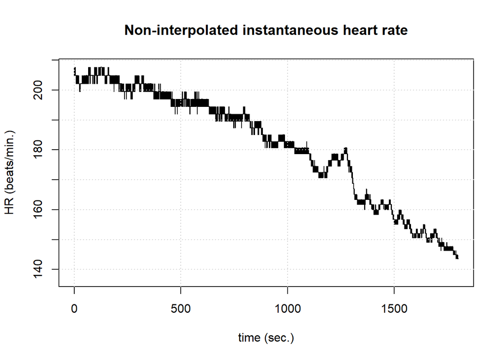

```r
PlotNIHR(hrv.data.inf)
```

With this cleaned data we will now proceed with the analysis

# Time-domain analysis

There are several outputs of the time domain analysis function.

The instantaneous heart rate is defined:

$$RR[i] = (Time[i] - Time[i - 1]) * 1000$$

$$HR(i) = \frac {1000} {RR[i]*60}$$

where $Time[i]$ is the time when the beat $i$ occurs, measured in seconds, $RR[i]$ is the beat-to-beat distance, measured in milliseconds, and $HR(i)$ is the instantaneous heart rate, measured in beats per minute.

The arithmetic mean of the RR interval series, RR, is be defined as follows:

$$\overline{RR}=\frac{1}{N}\sum_{i=1}^{n}RR_i$$
Being N the length of the RR series, and $RR_i$ the $RR$ interval between beats $i$ and $i-1$, where each beat position corresponds to the beat detection instant.

SDNN is the standard deviation of the RR interval series:

$$SDNN = \sqrt {\frac{1}{N-1} \sum_{i=1}^{n} (RR_i - \overline{RR})^2}$$

$SDNN$ reflects the global variability of the series. However, SDNN value depends on the length of the recording, and therefore, durations of recording should be standardized in order to obtain comparable results. We have chosen three 30 minute epochs and three 180 minute epochs.

Other time-domain measures are estimated from segments of the total recording, usually 5 min. For instance, $SDANN$ is the standard deviation of the means of these segments, while $SDNNIDX$ is the mean of the standard deviations of these same segments. To compute these indices, the RR series is divided into fragments 5 min long, and mean and standard deviation of RR distances can be calculated for each fragment:

$$\overline{RR}_s = \frac{1}{N_s} \sum_{i=1}^{N_s} RR_i$$

$$SDNN_s = \sqrt{ \frac{1}{N-1} \sum_{i=1}^{n} (RR_i - \overline{RR})^2}$$

where $RRs$ and $SDNNs$ are the mean and the standard deviation, respectively, of the $RR$ distances in fragment $s$, and $N$ is the number of elements in this fragment. As said, $SDANN$ is the standard deviation of the means of all the fragments, and $SDNNIDX$ is the mean of the standard deviations of all fragments:

$$\overline{RR}_{alls}=\frac{1}{m}\sum_{s=1}^{m}\overline{RR_s}$$

$$SDANN = \sqrt{ \frac{1}{m-1} \sum_{s=1}^{m} (RR_s - \overline{RR})^2}$$

$$SDNNIDX = \frac{1}{m} \sum_{s=1}^m SDNN_s$$

where $RR_{alls}$ is the mean of all segments, and $m$ is the total number of segments. $SDANN$ evaluates long-term variability, due to cycles longer than 5 min, and $SDNNIDX$ quantifies short-term variability, because of cycles shorter than 5 min.

Indicies based on the difference between adjacent RR values quantify the power due to high-frequency components. The most used are $pNN50$, $SDSD$, and $r-MSSD$. $pNN50$ is the proportion of values of the RR series that differ from the previous value more than 50 $ms$:

And $r-MSSD$ is defined as the square root of the mean of the squares of differences between adjacent $RR$ intervals:

$$\Delta{RR_j}=RR_{j+1}-RR_j$$

for, $j=1$

$$r-MSSD=\sqrt{\frac{1}{N-1}\sum_{j=i}^{N-1}\Delta RR_j^{2}}$$

These three short-term measurements estimate high-frequency variations and, therefore, show high correlation with each other. Other similar indices are $IRRR$ and $MADRR$, correlated with $SDNN$ and $pNN50$, respectively, and that solve some of their problems. $IRRR$ is the interquartile range, that is, the difference between the third and the first quartile of the RR series, and it is a very robust measure against artifacts:

$$IRRR=Q3(\Delta RR)-Q1(\Delta RR)$$

Quartiles are defined as the three values of the points that divide the ordered data set into four equally sized groups. The first quartile $(Q1)$ splits off the lowest 25% of the RR values, and the third quartile $(Q3)$ splits off the highest 25% of the RR values. If the RR series has a Gaussian distribution, $IRRR$ is an estimation of standard deviation (overall HRV). Though in the context of piglets with hypoxic-ischaemic brain injury and the resultant instability in the animals I don’t beleive it is safe to assume a gausian distribution in every epoch.

MADRR is the median of the absolute differences between adjacent RR values and does not suffer from saturation problems as pNN50. Similar to pNN50, MADRR measures the power due to high-frequency components. This median is calculated as the second quartile $(Q2)$ of $|\Delta RR|$:

$$MADRR = Q2(|\Delta RR|)$$

In addition to these statistical parameters, there are some geometric measures that can be estimated from the RR interval histogram, such as $TINN$ and the HRV index, in order to avoid the negative influence of artifacts in the determination of variability indexes. A bin of approximately 8 ms (exactly 7.8125 ms) can be used to construct smoothed histograms.

$TINN$ is the baseline width of the triangular interpolation of the RR intervals histogram. $TINN$ may be calculated as the total area of the histogram of the RR series, divided by the maximum of the histogram multiplied by 2:

$$TINN = \frac {N* bin size} {max(histogram(RR))} \cdot 2$$

An approximation to this measure is the $HRV index$. The HRV index is the integral of the intervals histogram (the number of all $RR$ intervals, that is, the length of the $RR$ series) divided by the maximum of the intervals histogram. The HRV index does not need triangular interpolation, and it is dimensionless:

$$HRV index = \frac{N} {max(histogram(RR))}$$

Both measures, $TINN$ and $HRV index$, reflect overall HRV and are more influenced by the lower than by the higher frequencies.

size: length of segments in which the RR series is divided (default: 300 seconds). numofbins: number of bins in RR histogram; when not specified, the interval parameter is used (default). interval: width of bins in RR histogram (default: 7.8125 ms).

```r
# Use the CreateTimeAnalysis function to calcualate the above defined statistics for each timepoint.
hrv.data.pre <- CreateTimeAnalysis(hrv.data.pre)
```

```
##  Creating time analysis
```

```
##  Size of window: 300 seconds
```

```
##  Width of bins in histogram: 7.8125 milliseconds
```

```
##  Number of windows: 5
```

```
##  Data has now 1 time analyses
##    SDNN: 8.1398 msec.
##    SDANN: 7.1252 msec.
##    SDNNIDX: 5.0739 msec.
##    pNN50: 0 %
##    SDSD: 3.1492 msec.
##    r-MSSD: 3.1489 msec.
##    IRRR: 11.7188 msec.
##    MADRR: 3.9062 msec.
##    TINN: 51.8192 msec.
##    HRV index: 3.3164
```

```r
hrv.data.HI <- CreateTimeAnalysis(hrv.data.HI)
```

```
##  Creating time analysis
```

```
##  Size of window: 300 seconds
```

```
##  Width of bins in histogram: 7.8125 milliseconds
```

```
##  Number of windows: 5
```

```
##  Data has now 1 time analyses
##    SDNN: 18.3771 msec.
##    SDANN: 4.6883 msec.
##    SDNNIDX: 11.7207 msec.
##    pNN50: 0 %
##    SDSD: 3.8964 msec.
##    r-MSSD: 3.8961 msec.
##    IRRR: 23.4375 msec.
##    MADRR: 3.9062 msec.
##    TINN: 74.1279 msec.
##    HRV index: 4.7442
```

```r
hrv.data.inf <- CreateTimeAnalysis(hrv.data.inf)
```

```
##  Creating time analysis
```

```
##  Size of window: 300 seconds
```

```
##  Width of bins in histogram: 7.8125 milliseconds
```

```
##  Number of windows: 5
```

```
##  Data has now 1 time analyses
##    SDNN: 34.9397 msec.
##    SDANN: 25.827 msec.
##    SDNNIDX: 7.2437 msec.
##    pNN50: 0 %
##    SDSD: 2.8355 msec.
##    r-MSSD: 2.8353 msec.
##    IRRR: 46.875 msec.
##    MADRR: 0 msec.
##    TINN: 87.249 msec.
##    HRV index: 5.5839
```

```r
###Calculate the range of the RR intervals in ms.
## This will be used as the maximum radius to calculate the correlation dimension later.
range.pre <- max(hrv.data.pre$Beat$RR)-min(hrv.data.pre$Beat$RR)
range.HI <- max(hrv.data.HI$Beat$RR)-min(hrv.data.HI$Beat$RR)
range.inf <- max(hrv.data.inf$Beat$RR)-min(hrv.data.inf$Beat$RR)
```

# Frequency analysis

To be able to study nonstationary signals, of which heart rate is one, several techniques capable of representing a signal in both time and frequency domain have been developed. The key idea behind these time-frequency joint representations is to define elementary time-frequency atoms as waveforms with minimum spread in the time-frequency plane. Then, these time-frequency atoms (instead of the infinite time spread sines and cosines) are used to decompose the signals. Selecting the time-frequency atoms is not a trivial problem because of the time-frequency uncertainty principle: The energy spread of a function and its Fourier Transform cannot simultaneously be arbitrarily small.

One of the most common time-frequency decompositions for discrete signals is the Short-Time Fourier Transform $(STFT)$, which uses a symmetric window to select an interval of the signal that is going to be analyzed. The remaining signal is analyzed by repeatedly shifting the window in time. Often these shifts are made in such a way that the multiple time-windows used have a certain degree of overlap between them. In order to sample the frequency interval with $M$ equally spaced frequencies, the practical implementation of the $STFT$ of the $RR$ series is given by:

$$X_{r,k} = \sum^{L-1}_{n=0} RR_{rR+n} \cdot w_ne^{-2 \pi ki \frac{n}{M}}$$

where r and k are integers fulfilling 0 $\leq$ r $\leq$ $[\frac{N-L-1}{R}]$ , N is the length of $x$, and R 0 $\leq$ k $\leq$ $M - 1$, and $w$ is the $L-point$ discrete window used in the analysis whose position moves in jumps of $R$ samples in time. To compute the $STFT$ efficiently, the width of window $w$ must be a highly composite number. Using a window with a small width provides good temporal resolution, at the cost of losing frequency resolution, especially in the lower frequencies. On the contrary, a wider window provides better spectral resolution at the expense of time resolution.

When HRV frequency analysis is performed using the $STFT$, there is an inherent tension between studying short-duration phenomena (e.g., apnea) that may be reflected in the higher frequency spectral bands $(LF and HF)$ and obtaining information on the lower frequency bands $(VLF and ULF)$. Because neonates have high power in the lower frequencies we want information about the $VLF$ band, and should use at least a 5-10 min window. To obtain a reliable estimation about the $ULF$ band, I should use an even wider window. A common practice in these scenarios is to perform two frequency analyses. The first one uses a wide window that provides reliable information on the $VLF$ and $ULF$ bands, but it is not capable of extracting information about short-duration phenomenon. The second analysis uses a narrow window that can capture the effect of short-duration phenomenon on the $LF$ and $HF$ bands, but it does not provide a good estimation of the $VLF$ and $ULF$ bands. A better solution to this problem is to use the wavelet Transform $(WT)$. A wavelet is a “small wave” with zero mean that grows and decays in a limited time period. A function fulfilling these conditions is called “mother wavelet.” The mother wavelet can be scaled and shifted in time, yielding a set of wavelet functions with different sizes and centered in different time positions:

$$\psi_{u,s}(t) = \frac {1} {\sqrt{s}}\psi(\frac{t-u}{s})$$

where $s$ is positive and defines the scale, and u is any real number defining the shift. This set of functions is used to extract time-frequency information by correlating them with the signal $f (t)$ being analyzed:

$$[W_{\psi} f](u,s) = \frac{1}{\sqrt{s}} \int^{\infty}_{-\infty} \psi (\frac{t-u}{s}) f(t) dt$$

where $[W_{\psi} f](u, s)$ is the $WT$ of the signal $f (t)$ using the mother wavelet ${\psi}$. When working with discrete signals, and if the proper set of orthonormal wavelets is used in the decomposition, it is possible to efficiently compute the $WT$ as a set of conjugate mirror filters and subsampling operations.

The $WT$ provides a better compromise between time and frequency resolution than the $STFT$. The $STFT$ uses just one window to analyze the signal. However, the ideal approximation would be to use narrow windows at high frequencies, and wide windows at low frequencies. The Wavelet Transform uses multiple windows, obtained by applying dilatations to the mother wavelet, leading to a multiresolution analysis. In the literature, there are more $HRV$ studies that use the $STFT$ than studies that use the WT, despite the theoretically superior properties of the latter. We will use both techniques and compare the results.

```
##  Plotting spectrogram
```

```
##  Calculating spectrogram
```

```
##  Window: 4800 samples (shift: 480 samples)
```

```
##  Window size for calculation: 8192  samples (zero padding: 3392  samples)
```

```
##  Signal size: 14397 samples
```

```
##  Windowing signal with 20 windows
```

```
##  Spectrogram calculated
```

```
##  Spectrogram plotted
```

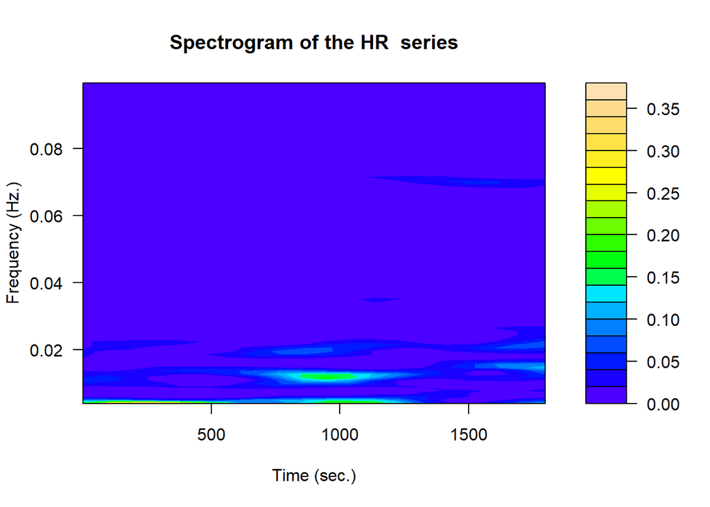

```r
#Plot the spectrogram of each time segment
spectrogram.pre <- PlotSpectrogram(hrv.data.pre, size = 600, shift = 60, scale = "logaritmic", freqRange = c(0.003, .1))
```

```
##  Plotting spectrogram
```

```
##  Calculating spectrogram
```

```
##  Window: 4800 samples (shift: 480 samples)
```

```
##  Window size for calculation: 8192  samples (zero padding: 3392  samples)
```

```
##  Signal size: 14399 samples
```

```
##  Windowing signal with 20 windows
```

```
##  Spectrogram calculated
```

```
##  Spectrogram plotted
```

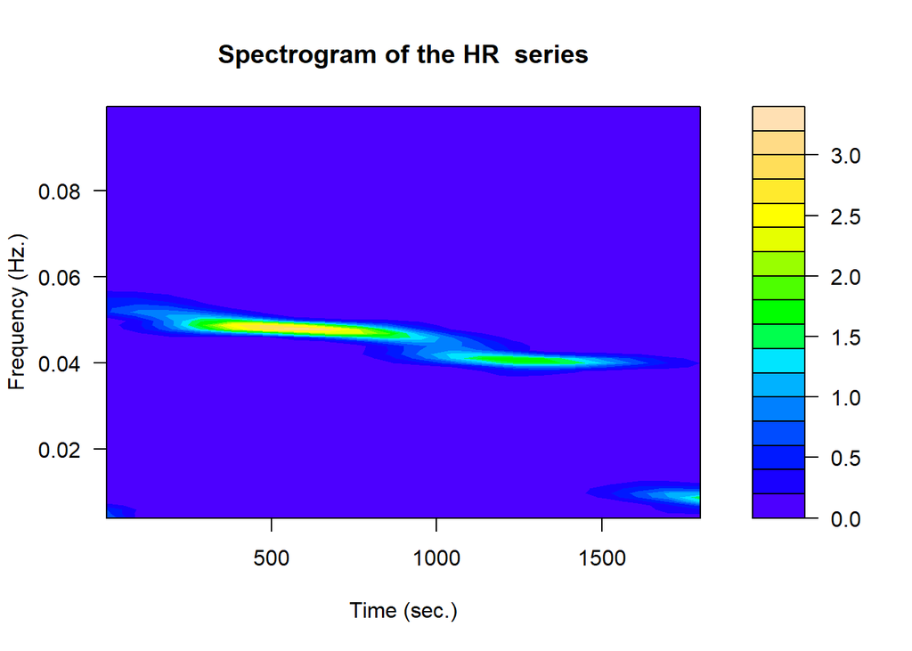

```r
spectrogram.HI <- PlotSpectrogram(hrv.data.HI, size = 600, shift = 60, scale = "logaritmic", freqRange = c(0.003, .1))
```

```
##  Plotting spectrogram
```

```
##  Calculating spectrogram
```

```
##  Window: 4800 samples (shift: 480 samples)
```

```
##  Window size for calculation: 8192  samples (zero padding: 3392  samples)
```

```
##  Signal size: 14399 samples
```

```
##  Windowing signal with 20 windows
```

```
##  Spectrogram calculated
```

```
##  Spectrogram plotted
```

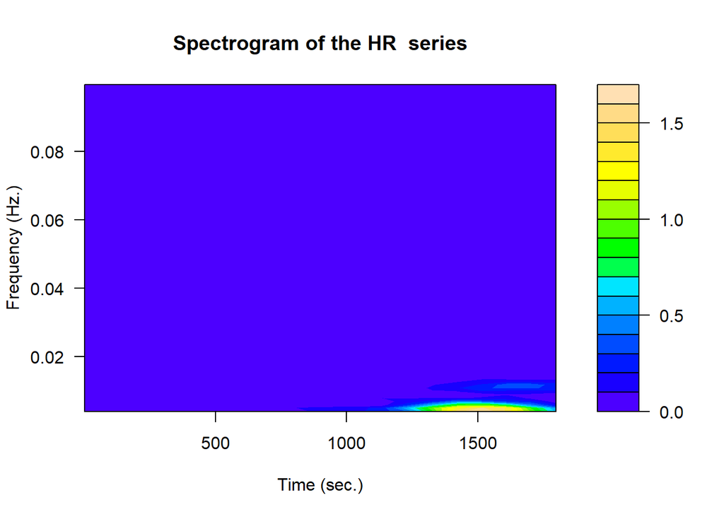

```r
spectrogram.inf <- PlotSpectrogram(hrv.data.inf, size = 600, shift = 60, scale = "logaritmic", freqRange = c(0.003, .1))
```

```
##  Calculating Periodogram using DFT + Daniell smoothers
```

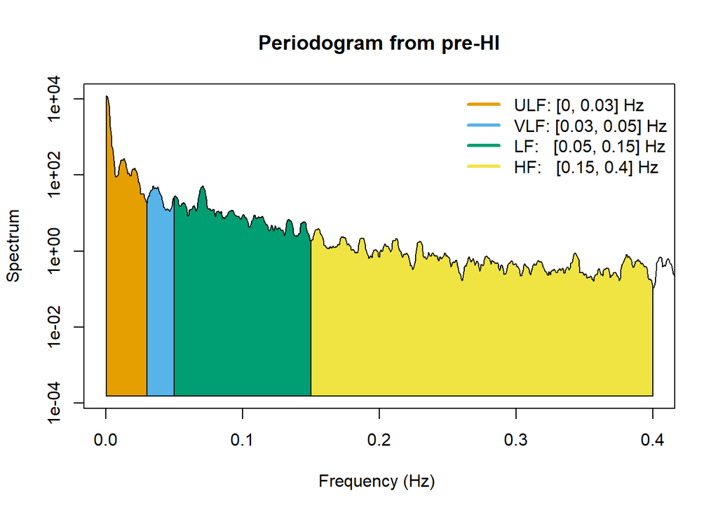

```r
# Periodogram using DFT and Daniell smoothers
hrv.data.pre <- CalculatePSD(hrv.data.pre, indexFreqAnalysis = 1, method = "pgram",
    spans = 9, doPlot = T, main = "Periodogram from pre-HI")
```

```
##  Calculating Periodogram using DFT + Daniell smoothers
```

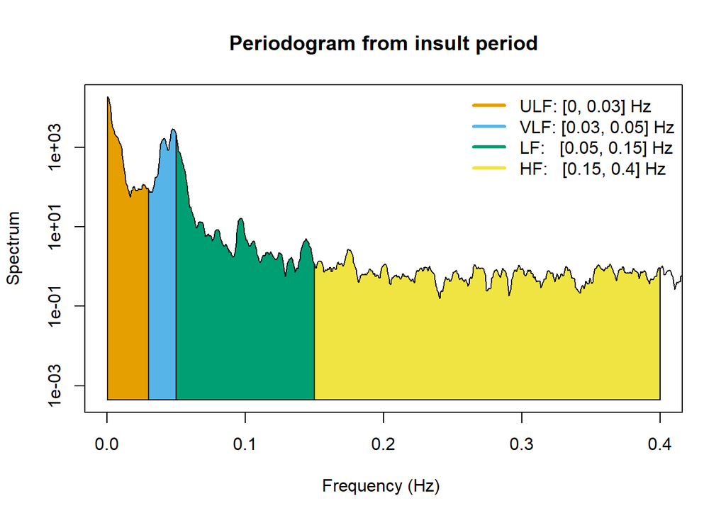

```r
hrv.data.HI <- CalculatePSD(hrv.data.HI, indexFreqAnalysis = 1, method = "pgram",
    spans = 9, doPlot = T, main = "Periodogram from insult period")
```

```
##  Calculating Periodogram using DFT + Daniell smoothers
```

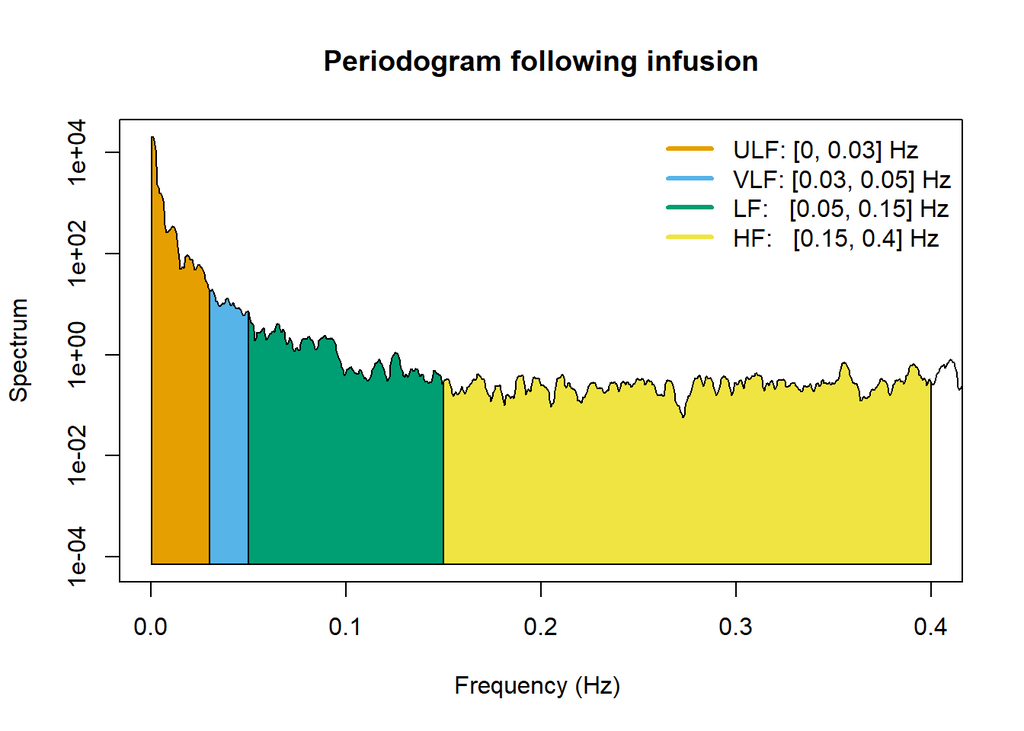

```r
hrv.data.inf <- CalculatePSD(hrv.data.inf, indexFreqAnalysis = 1, method = "pgram",
    spans = 9, doPlot = T, main = "Periodogram following infusion")
```

## Create powerband using wavelets

The most important function to perform nonstationary spectral HRV analysis is the CalculatePowerBand function. The CalculatePowerBand function computes the spectrogram of the RR series in the $ULF$, $VLF$, $LF$, and $HF$ frequency bands using $STFT$ or wavelets.

Internally, the CalculatePowerBand function computes the spectrogram by using either $STFT$ or wavelets. The type of analysis can be selected by the user by specifying the type parameter. The possible values of this parameter are “fourier” or “wavelet”. Although the analysis based on wavelets is theoretically superior and more suitable for nonstationary signals, to maintain backwards compatibility in RHRV the default value for this parameter is “fourier”. In the following subsections, we will see the parameters that can be specified when performing the analysis using Fourier and wavelets.

Given that the RR series is not stationary, it is often interesting to analyze the temporal evolution of the spectral power in the different bands. However, if the recording analyzed is short, or if we assume approximately stationary conditions over the recording, we may be interested in working with the average values of the spectral power in each of the bands. These average values are also computed by the function CalculatePowerBand and stored in the fields $ULF_{mean}$, $VLF_{mean}$, $LF_{mean}$, $HF_{mean}$, and $LFHF_{mean}$.

In the wavelet parameter, the name of the wavelet specifies the family (the family determines the shape of the wavelet and its properties) and the length of the wavelet. For example, $"la8"$ belongs to the least asymmetric family and has a length of 8 samples. Shorter wavelets usually have better temporal resolution, but they will tend to fail when discriminating close frequencies. On the other hand, longer wavelets usually have worse temporal resolution, but they provide better frequency resolution. Better temporal resolution means that we can study shorter-time intervals. Depending on the goal of the analysis, we can choose longer or shorter wavelets within a wavelet family.

Let $[fl,fu]$ be any frequency band specified, and let $[f1,f2]$ be a frequency interval associated with some node in the Maximal Overlap Discrete Wavelet Packet Transform $(MODWPT)$ tree. The relative error $Îµr$ of $fl$ over the $[f1,f2]$ interval is computed as:

$$\epsilon_r = |\frac{f_l-f_1}{f_u-f_l}|\cdot100%$$
Similarly, the relative error $\epsilon_r$ of the upper frequency $f_u$ is:
$$\epsilon_r = |\frac{f_u-f_2}{f_u-f_l}|\cdot100%$$

The use of a relative error has the advantage of avoiding large errors in the lower frequency bands (ULF and VLF bands). The absolute value $\epsilon$ is defined as usual: $\epsilon = |f2-f_u|$ for the upper frequency and $\epsilon = |f_1 - f_l|$ for the lower frequency.

Since the energy is concentrated in the ULF band, the spectrogram representation may be hiding interesting information on the other bands (because its energy is negligible compared to the energy in the ULF band). Ploting the spectrogram ignoring the energy in the lower frequencies components can negate this.

## Create powerband using extremal phase Daubechies of width 4 wavelets

```r
# Calculate the powerbands using the Daubachies Wavelet
hrv.data.pre = CalculatePowerBand(hrv.data.pre, indexFreqAnalysis = 1, type = "wavelet",
    wavelet = "d4", bandtolerance = 0.0025, relative = FALSE, ULFmin = 0, ULFmax = 0.01,
    VLFmin = 0.01, VLFmax = 0.04, LFmin = 0.04, LFmax = 0.45, HFmin = 0.55,
    HFmax = 2)
```

```
##  Calculating power per band
```

```
##  Using Wavelet analysis
```

```
##  Power per band calculated
```

```
##  Plotting power per band
```

```
##  Plotted LF/HF
```

```
##  Plotted ULF
```

```
##  Plotted VLF
```

```
##  Plotted LF
```

```
##  Plotted HF
```

```
##  Power per band plotted
```

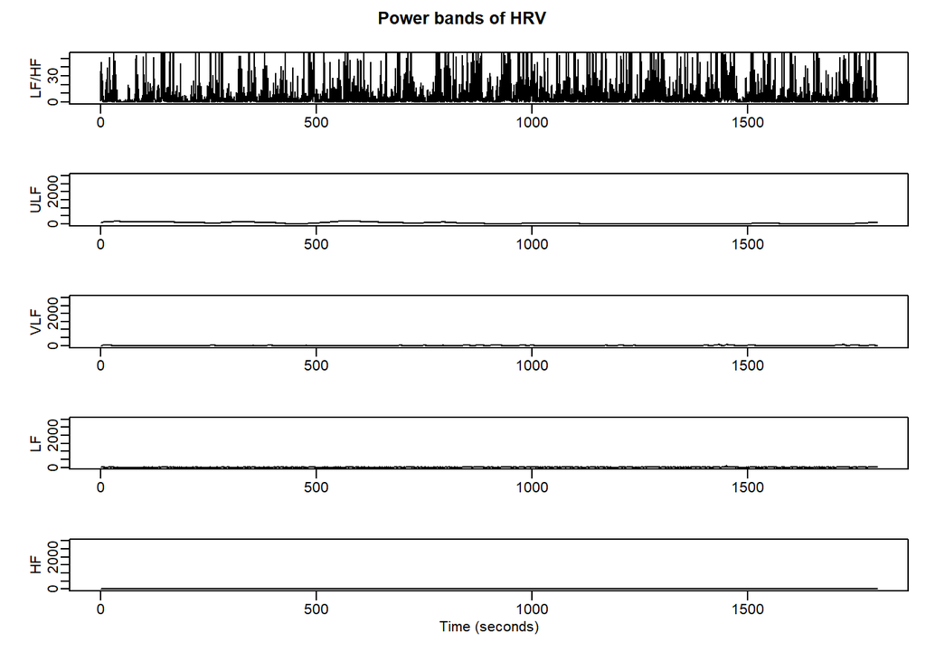

```r
# Plot powerbands
PlotPowerBand(hrv.data.pre, indexFreqAnalysis = 1, ymax = 3000, ymaxratio = 50,
    Tags = "all")
```

```r
hrv.data.HI = CalculatePowerBand(hrv.data.HI, indexFreqAnalysis = 1, type = "wavelet",
    wavelet = "d4", bandtolerance = 0.0025, relative = FALSE, ULFmin = 0, ULFmax = 0.01,
    VLFmin = 0.01, VLFmax = 0.04, LFmin = 0.04, LFmax = 0.45, HFmin = 0.55,
    HFmax = 2)
```

```
##  Calculating power per band
```

```
##  Using Wavelet analysis
```

```
##  Power per band calculated
```

```
##  Plotting power per band
```

```
##  Plotted LF/HF
```

```
##  Plotted ULF
```

```
##  Plotted VLF
```

```
##  Plotted LF
```

```
##  Plotted HF
```

```
##  Power per band plotted
```

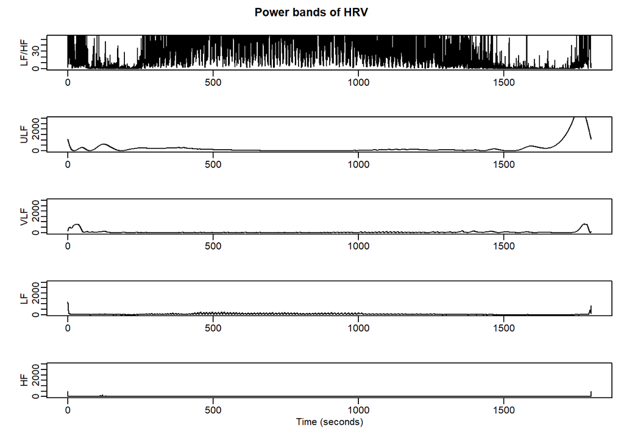

```r
PlotPowerBand(hrv.data.HI, indexFreqAnalysis = 1, ymax = 3000, ymaxratio = 50,
    Tags = "all")
```

```r
hrv.data.inf = CalculatePowerBand(hrv.data.inf, indexFreqAnalysis = 1, type = "wavelet",
    wavelet = "d4", bandtolerance = 0.0025, relative = FALSE, ULFmin = 0, ULFmax = 0.01,
    VLFmin = 0.01, VLFmax = 0.04, LFmin = 0.04, LFmax = 0.45, HFmin = 0.55,
    HFmax = 2)
```

```
##  Calculating power per band
```

```
##  Using Wavelet analysis
```

```
##  Power per band calculated
```

```
##  Plotting power per band
```

```
##  Plotted LF/HF
```

```
##  Plotted ULF
```

```
##  Plotted VLF
```

```
##  Plotted LF
```

```
##  Plotted HF
```

```
##  Power per band plotted
```

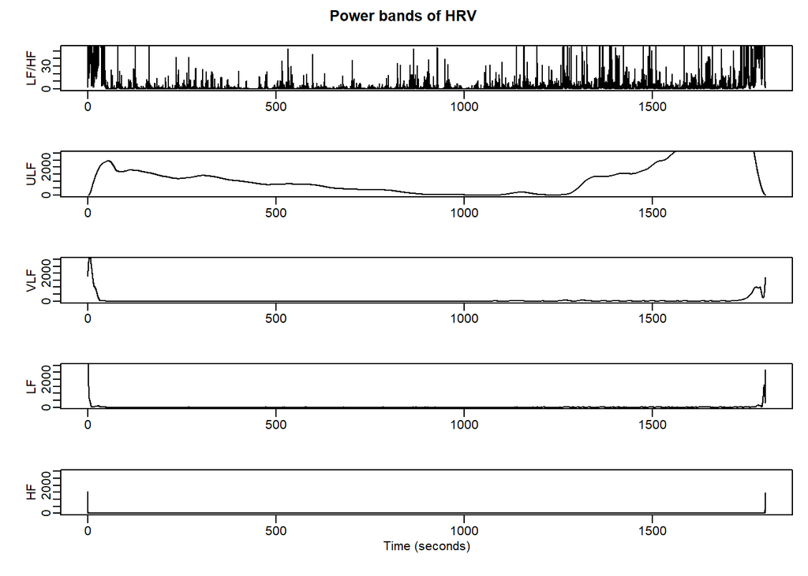

```r
PlotPowerBand(hrv.data.inf, indexFreqAnalysis = 1, ymax = 3000, ymaxratio = 50,
    Tags = "all")
```

## Create powerband using Short Time Fourier Transform

```r
# Calculate the powerbands using the Fourier transform
hrv.data.pre = CalculatePowerBand(hrv.data.pre, indexFreqAnalysis = 1, type = "fourier",
    shift = 25, size = 30, bandtolerance = 0.0025, relative = FALSE, ULFmin = 0,
    ULFmax = 0.01, VLFmin = 0.01, VLFmax = 0.04, LFmin = 0.04, LFmax = 0.45,
    HFmin = 0.55, HFmax = 2)
```

```
##  Calculating power per band
```

```
##  Using Fourier analysis
```

```
##  Windowing signal... 71 windows
```

```
##  Power per band calculated
```

```
##  Plotting power per band
```

```
##  Plotted LF/HF
```

```
##  Plotted ULF
```

```
##  Plotted VLF
```

```
##  Plotted LF
```

```
##  Plotted HF
```

```
##  Power per band plotted
```

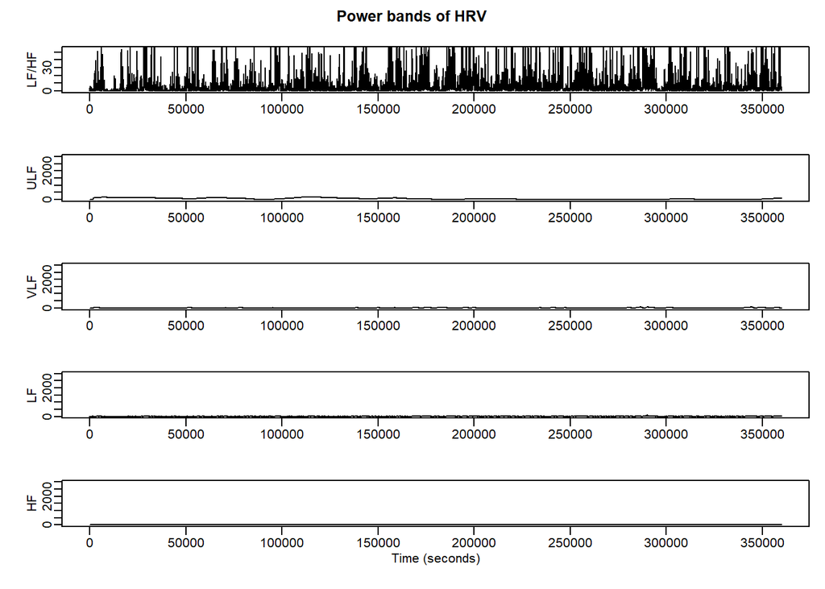

```r
# Plot powerbands
PlotPowerBand(hrv.data.pre, indexFreqAnalysis = 1, ymax = 3000, ymaxratio = 50,
    Tags = "all")
```

```r
hrv.data.HI = CalculatePowerBand(hrv.data.HI, indexFreqAnalysis = 1, type = "fourier",
    shift = 25, size = 30, bandtolerance = 0.0025, relative = FALSE, ULFmin = 0,
    ULFmax = 0.01, VLFmin = 0.01, VLFmax = 0.04, LFmin = 0.04, LFmax = 0.45,
    HFmin = 0.55, HFmax = 2)
```

```
##  Calculating power per band
```

```
##  Using Fourier analysis
```

```
##  Windowing signal... 71 windows
```

```
##  Power per band calculated
```

```
##  Plotting power per band
```

```
##  Plotted LF/HF
```

```
##  Plotted ULF
```

```
##  Plotted VLF
```

```
##  Plotted LF
```

```
##  Plotted HF
```

```
##  Power per band plotted
```

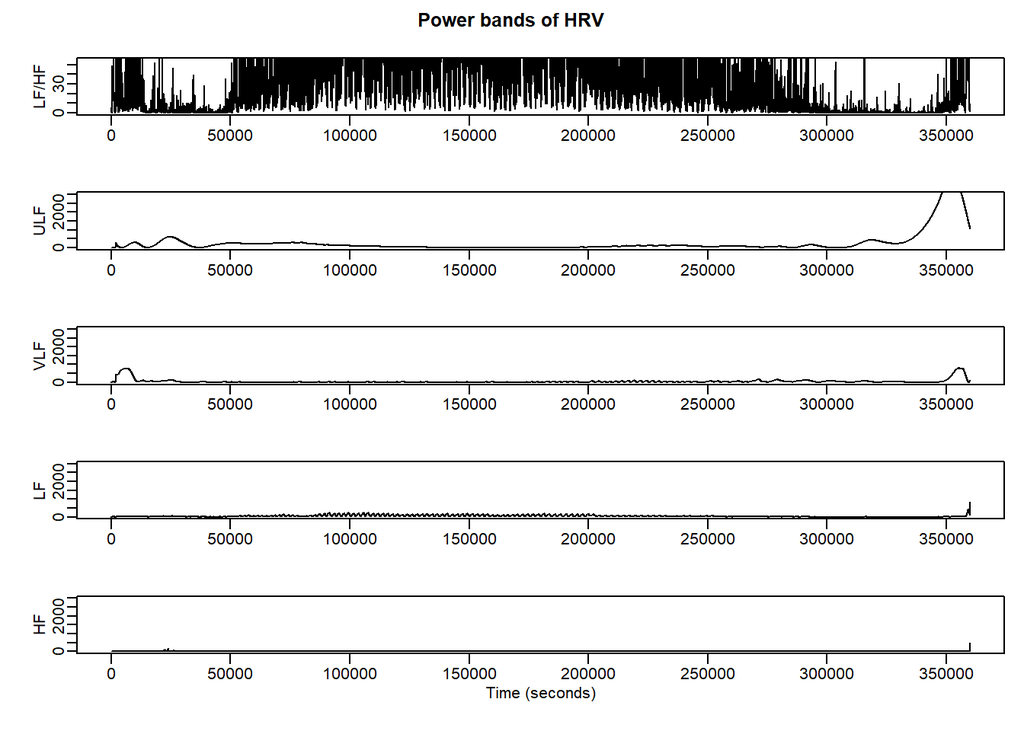

```r
PlotPowerBand(hrv.data.HI, indexFreqAnalysis = 1, ymax = 3000, ymaxratio = 50,
    Tags = "all")
```

```r
hrv.data.inf = CalculatePowerBand(hrv.data.inf, indexFreqAnalysis = 1, type = "fourier",
    shift = 25, size = 30, bandtolerance = 0.0025, relative = FALSE, ULFmin = 0,
    ULFmax = 0.01, VLFmin = 0.01, VLFmax = 0.04, LFmin = 0.04, LFmax = 0.45,
    HFmin = 0.55, HFmax = 2)
```

```
##  Calculating power per band
```

```
##  Using Fourier analysis
```

```
##  Windowing signal... 71 windows
```

```
##  Power per band calculated
```

```
##  Plotting power per band
```

```
##  Plotted LF/HF
```

```
##  Plotted ULF
```

```
##  Plotted VLF
```

```
##  Plotted LF
```

```
##  Plotted HF
```

```
##  Power per band plotted
```

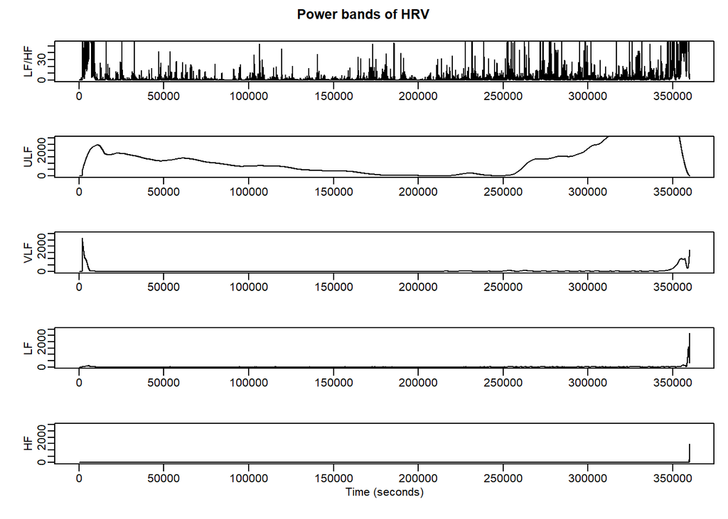

```r
PlotPowerBand(hrv.data.inf, indexFreqAnalysis = 1, ymax = 3000, ymaxratio = 50,
    Tags = "all")
```

# Non-Linear analysis

## An overview of nonlinear dynamics

Most nonlinear time series analysis techniques used in the HRV literature are motivated by the theory of dynamical systems. A dynamical system is represented by a set of n state variables (that can be represented as coordinates in Rn) that fully describe the state of the system at any time, and a dynamical rule that specifies the future values of all the state variables. The collection of coordinates is usually referred to as the phase space if these coordinates form a smooth manifold. There can be multiple spaces of states representing a dynamical system; i.e., the system representation is not unique. Dynamical systems can be deterministic (the future state is fully determined by the dynamical rule), or stochastic/random (there is a probability distribution defined over the future states).

In the context of HRV analysis, many successful approaches assume that the RR series is a deterministic nonlinear process (with possibly a small linear random perturbation). In this analysis, when applying techniques derived from deterministic nonlinear dynamics to the $RR$ series, I shall assume that the HR regulation system is dissipative, and thus, the system will be attracted, after some transient, to a subset attractor. Furthermore, we will focus on discrete deterministic dynamical systems, given that the major approach in $HRV$ literature focuses on studying how the current RR interval, $RRi$, determines the next one, $RRi+1$.

Nonlinear stochastic systems can be viewed as a combination of deterministic systems and stochastic models. There is a low use of nonlinear stochastic models in HRV due to the success in the application of a particular type of stochastic processes to the $RR$ series: fractal models.

## Hypothesis testing (Are we sure we are dealing with nonlinear signals?)

We first need to reject the null hypothesis: “This dataest was generated by some collection of linear processes”

The main idea for testing for nonlinearity is the following. A statistic $\mu$ quantifying some nonlinear feature of the data is computed. Does the value found for $\mu$ $(\mu_{data})$ suggest nonlinearity or can we explain this value with a simpler hypothesis? If we know the distribution of $\mu$ for a linear process, we can test if $\mu$ data gives enough evidence for assuming a nonlinear model. However, we do not usually know the distribution of $\mu$ under the null hypothesis. The preferred approach in the literature is estimating this distribution by using an ensemble of surrogate data.

This ensemble is generated in such a way that each realization shares the linear properties of the original time series. For a two-sided test and a level of significance $\alpha,$ $2K/\alpha- 1$ surrogates are usually generated (K is an integer, $K > 1$, controlling the final number of surrogates). Under the null hypothesis, there are $2K/\alpha$ samples following the same distribution. The null hypothesis is then rejected when the observed time series yields either one of the K smallest or largest values. For a one-sided test, only $K /\alpha - 1$ surrogates are needed, and we reject the null hypothesis when the time series yields one of the $K$ smallest/largest value(depending on the particular hypothesis).

To do this we will employ a variety of statistical tests: . Teraesvirta’s neural metwork test for nonlinearity . White neural metwork test for nonlinearity . Keenan’s one-degree test for nonlinearity . Perform the McLeod-Li test for conditional heteroscedascity (ARCH). . Perform the Tsay’s test for quadratic nonlinearity in a time series. . Perform the Likelihood ratio test for threshold nonlinearity.

These tests the null hypothesis stating that the series is a gaussian linear process or was generated by some combination of linear processes. The test is performed by generating several surrogate data according to H0 and comparing the values of a discriminating statistic between both original data and the surrogate data. If the value of the statistic is significantly different for the original series than for the surrogate set, the null hypothesis is rejected, and nonlinearity assumed.

The surrogate data is generated by using a phase randomization procedure. $\alpha = 0.05$, $timeAsymmetry = 2$, $\tau = 4$

And while we may not always be able to reject the null hypothesis, this pipeline provides a reproducible value that may still be useful.

```
##  Performing nonlinearity tests
```

```
##       ** Teraesvirta's neural network test  **
##       Null hypothesis: Linearity in "mean"
##       X-squared =  165.1173  df =  2  p-value =  0
##
##       ** White neural network test  **
##       Null hypothesis: Linearity in "mean"
##       X-squared =  144.5825  df =  2  p-value =  0
##
##       ** Keenan's one-degree test for nonlinearity  **
##       Null hypothesis: The time series follows some AR process
##       F-stat =  9.691579  p-value =  0.001859565
##
##       ** McLeod-Li test  **
##       Null hypothesis: The time series follows some ARIMA process
##       Maximum p-value =  0
##
##       ** Tsay's Test for nonlinearity **
##       Null hypothesis: The time series follows some AR process
##       F-stat =  1.524  p-value =  3.03e-14
##
##       ** Likelihood ratio test for threshold nonlinearity **
##       Null hypothesis: The time series follows some AR process
##       Alternativce hypothesis: The time series follows some TAR process
##       X-squared =  97.98423  p-value =  5.572941e-06
```

```
## Computing statistics
```

```
## Null Hypothesis: Data comes from a linear stochastic process
```

```
## Reject Null hypothesis:
##      Original data's stat is significant larger than surrogates' stats
```

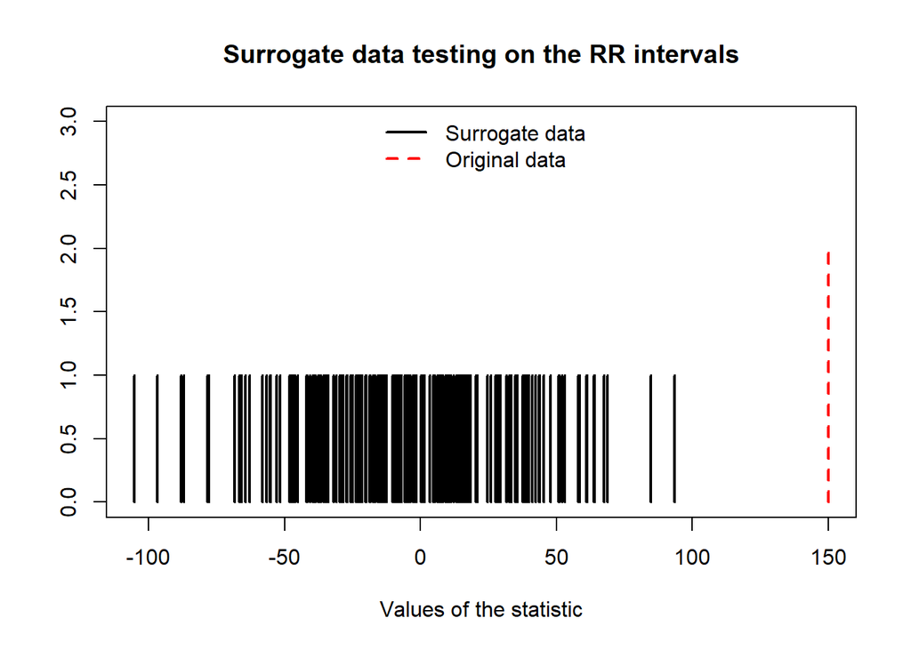

```
## Computing statistics
```

```
## Null Hypothesis: Data comes from a linear stochastic process
```

```
## Reject Null hypothesis:
##      Original data's stat is significant larger than surrogates' stats
```

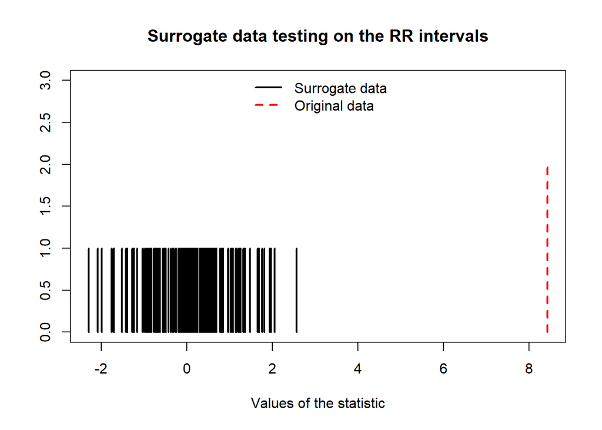

```
##  Performing nonlinearity tests
```

```
##       ** Teraesvirta's neural network test  **
##       Null hypothesis: Linearity in "mean"
##       X-squared =  16.96739  df =  2  p-value =  0.0002068126
##
##       ** White neural network test  **
##       Null hypothesis: Linearity in "mean"
##       X-squared =  9.032472  df =  2  p-value =  0.01093009
##
##       ** Keenan's one-degree test for nonlinearity  **
##       Null hypothesis: The time series follows some AR process
##       F-stat =  0.0006199674  p-value =  0.9801362
##
##       ** McLeod-Li test  **
##       Null hypothesis: The time series follows some ARIMA process
##       Maximum p-value =  0
##
##       ** Tsay's Test for nonlinearity **
##       Null hypothesis: The time series follows some AR process
##       F-stat =  5.029  p-value =  1.763e-278
##
##       ** Likelihood ratio test for threshold nonlinearity **
##       Null hypothesis: The time series follows some AR process
##       Alternativce hypothesis: The time series follows some TAR process
##       X-squared =  660.5253  p-value =  0
```

```
## Computing statistics
```

```
## Null Hypothesis: Data comes from a linear stochastic process
```

```
## Reject Null hypothesis:
##      Original data's stat is significant larger than surrogates' stats
```

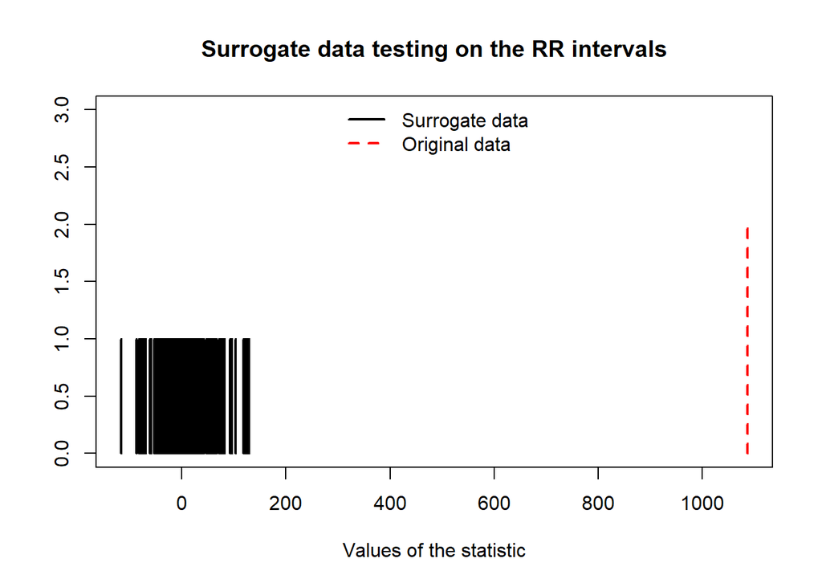

```
## Computing statistics
```

```
## Null Hypothesis: Data comes from a linear stochastic process
```

```
## Reject Null hypothesis:
##      Original data's stat is significant larger than surrogates' stats
```

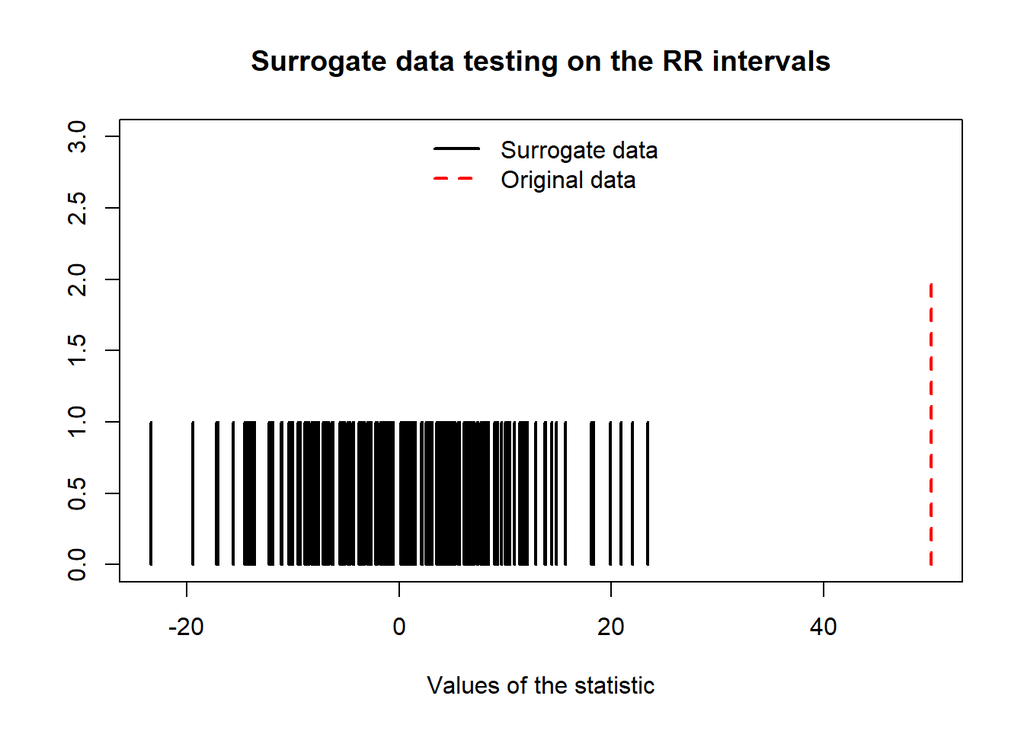

```
##  Performing nonlinearity tests
```

```
##       ** Teraesvirta's neural network test  **
##       Null hypothesis: Linearity in "mean"
##       X-squared =  40.17036  df =  2  p-value =  1.892856e-09
##
##       ** White neural network test  **
##       Null hypothesis: Linearity in "mean"
##       X-squared =  32.81529  df =  2  p-value =  7.486023e-08
##
##       ** Keenan's one-degree test for nonlinearity  **
##       Null hypothesis: The time series follows some AR process
##       F-stat =  1.747201  p-value =  0.186285
##
##       ** McLeod-Li test  **
##       Null hypothesis: The time series follows some ARIMA process
##       Maximum p-value =  0
##
##       ** Tsay's Test for nonlinearity **
##       Null hypothesis: The time series follows some AR process
##       F-stat =  3.253  p-value =  6.815e-29
##
##       ** Likelihood ratio test for threshold nonlinearity **
##       Null hypothesis: The time series follows some AR process
##       Alternativce hypothesis: The time series follows some TAR process
##       X-squared =  262.1541  p-value =  0
```

```
## Computing statistics
```

```
## Null Hypothesis: Data comes from a linear stochastic process
```

```
## Reject Null hypothesis:
##      Original data's stat is significant larger than surrogates' stats
```

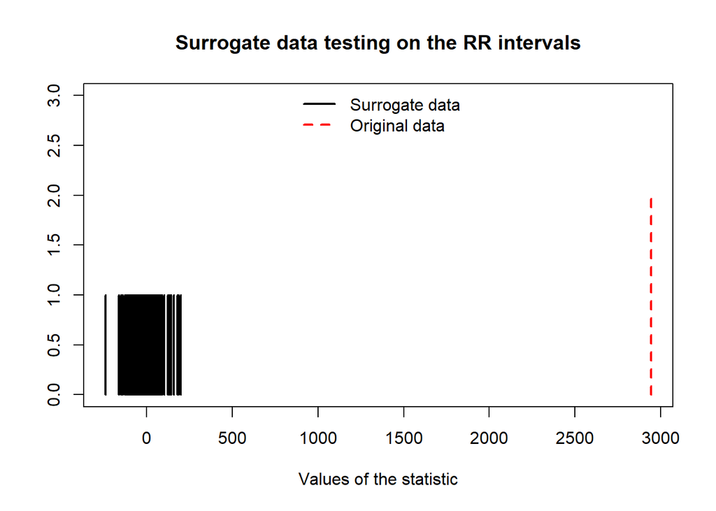

```
## Computing statistics
```

```
## Null Hypothesis: Data comes from a linear stochastic process
```

```
## Accept Null hypothesis
```

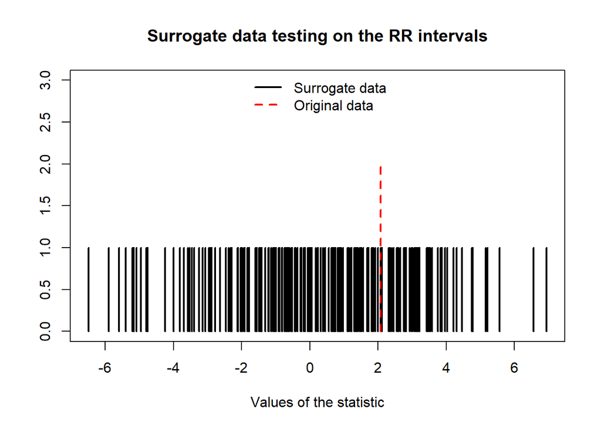

## Phase space reconstruction

When observing a highly complex system (such as the HR modulation system), typically I am only able to measure a few of the dynamical variables governing the evolution of the system. In the case of HRV analysis, I usually only measure the RR intervals instead of the (unknown) set of state variables. This problem receives the name of phase space reconstruction, and it is formally solved by using the embedding theorem. This theorem states that a phase space can be reconstructed from the single measured discrete series $x_i$ by using the vectors:

$$xi = [xi , x_{i+\tau} , ..., x_{i+(m-1)}\cdot\tau] ,$$

where $m$ and $\tau$ will be referred to as the $embedding dimension$ and the $time-lag parameter$.

Great effort has been made to clarify under which circumstances leads to proper phase space reconstruction. This is guaranteed if $m$ is larger than twice the dimension of the true phase space. However, the true embedding dimension of the attractor is usually unknown in practical applications. The most widely used method for selecting the embedding dimension is based on the concept of false neighbour. Let us suppose that I have built a phase space reconstruction using an embedding dimension $m$ and a time lag $\tau$ . Given a specific vector $x_i$, I shall denote its nearest neighbor in the phase space by $x^{nn}_{i}$. If $xnn$ is a true neighbor of $x_i$, then it should have arrived to a neighborhood of $x_i$ through the dynamical rules of the system. On the other hand, if $x^{nn}$ is a false neighbor, then it may have arrived to a neighborhood of $x_i$ because during the phase space reconstruction process I have projected the $d$-dimensional attractor into an $m$-dimensional space, $d > m$. If I have false neighbors in a given reconstruction, by increasing the dimension of the reconstructed phase space, I should decrease the number of false neighbors. When I reach the real dimension, only the real neighbors should remain in the neighborhood of the point, while false neighbors should disappear. Henceforth, increasing the size of the reconstructed space should not decrease the number of neighbors. Thus, the key idea behind the most widely used algorithms for selecting a proper phase space dimension is searching for the minimum dimension in which most of the false neighbors have been eliminated. RHRV package implements one of the best-known algorithm based on false neighbors, the Cao algorithm.

Selecting a proper time lag parameter $\tau$ is also important when embedding the vectors in an $m$-dimensional phase space. If $\tau$ is small compared to the time scale that the system needs to manifest noticeable changes, successive elements of the phase space will be highly correlated. Thus, they will tend to cluster around the diagonal of $\mathbb{R} m$ . On the other hand, if $\tau$ is too large, the phase space elements will be independent; thus, the resulting embedding will tend to spread in $\mathbb{R}m$ . The first zero in the autocorrelation function of the signal is often selected as a compromise between these extreme situations. The first minimum or the $1/e$ value of the autocorrelation function is also used as selection criterion for $\tau$ .

In the next sections, a brief theoretical discussion of the nonlinear deterministic techniques implemented in RHRV is presented.

According to Taken’s therom, it is possible to build a smooth attractor from observations of a general function. The correctly generated manifold reconstruction will have the same mathematical properties such as its topological characteristics and Lyapunov exponent.

To perform the phase space reconstruction I need to define two variables, the timelag of the function and the dimension in which the embed the manifold reconstruction.

To calculate the $\tau$ I will use the $AMI$ algorithm.

A basic criterion for estimating a proper time lag is based on the following reasoning: if the time lag used to build the Takens’ vectors is too small, the coordinates will be too highly temporally correlated and the embedding will tend to cluster around the diagonal in the phase space.

Estimation of the Embedding dimension This function determines the minimum embedding dimension from a scalar time series using the algorithm proposed by L. Cao. The Cao algorithm computes two time series ($E1D$ and $E2D$). The $E1D$ time series will reach a value of one and stay at 1 when proper phase space reconstruction has been achieved. $ED2 \approx 1$ when the data is stochastic and is otherwise deterministic.

Due to the low sampling rate, we must reduce the noise component.

```
##  Calculating optimum time lag
```

```
##  Time Lag = 13
```

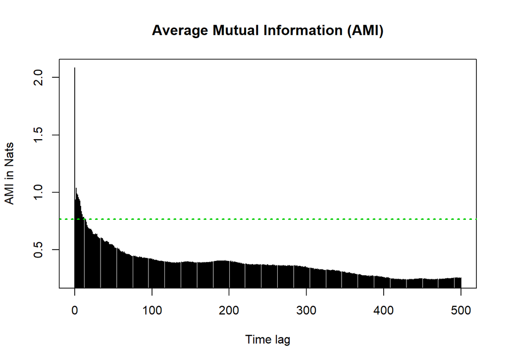

```r
# These functions calculate the time lag and the embedding dimension used to
# perform phase space reconstruction
kTimeLag = CalculateTimeLag(hrv.data.pre, technique = "ami", method = "first.e.decay",
    lagMax = 500, doPlot = TRUE)
```

```
##  Estimating embedding dimension
```

```
##  Embedding Dimension = 13
```

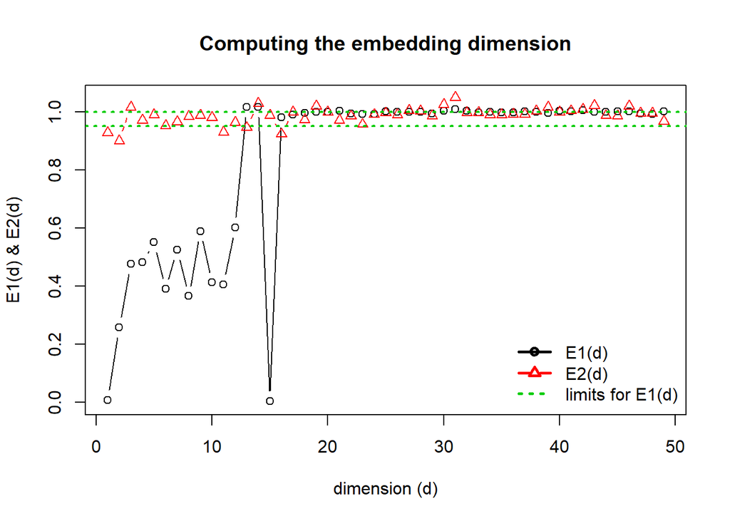

```r
kEmbeddingDim = CalculateEmbeddingDim(hrv.data.pre, numberPoints = 1000, timeLag = kTimeLag,
    maxEmbeddingDim = 50, threshold = 0.95, maxRelativeChange = 0.2, doPlot = TRUE)
```

```
##  Calculating optimum time lag
```

```
##  Time Lag = 11
```

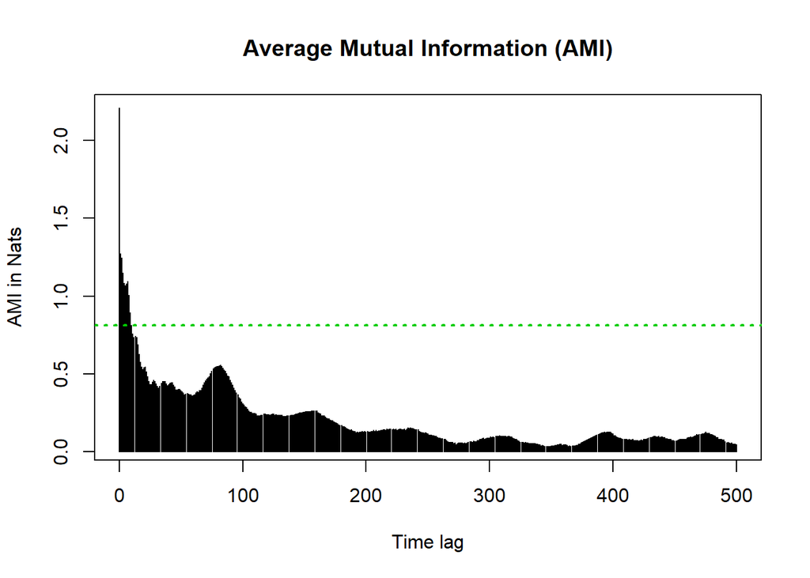

```r
kTimeLag.HI = CalculateTimeLag(hrv.data.HI, technique = "ami", method = "first.e.decay",
    lagMax = 500, doPlot = TRUE)
```

```
##  Estimating embedding dimension
```

```
##  Embedding Dimension = 12
```

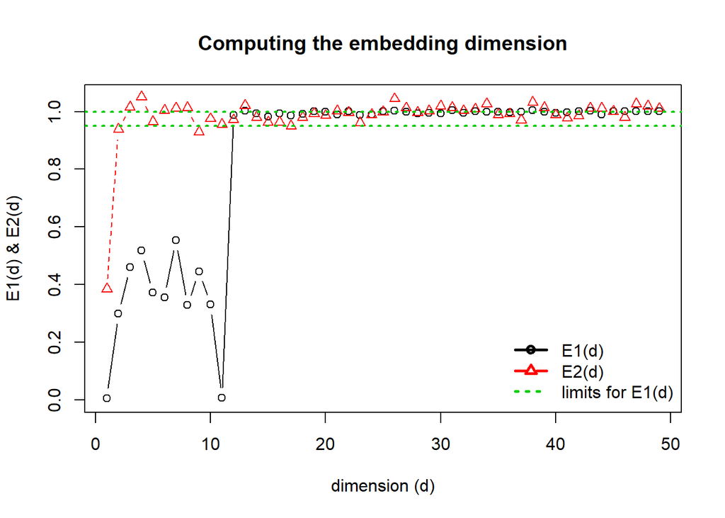

```r
kEmbeddingDim.HI = CalculateEmbeddingDim(hrv.data.HI, numberPoints = 1000, timeLag = kTimeLag,
    maxEmbeddingDim = 50, threshold = 0.95, maxRelativeChange = 0.1, doPlot = TRUE)
```

```
##  Calculating optimum time lag
```

```
##  Time Lag = 1
```

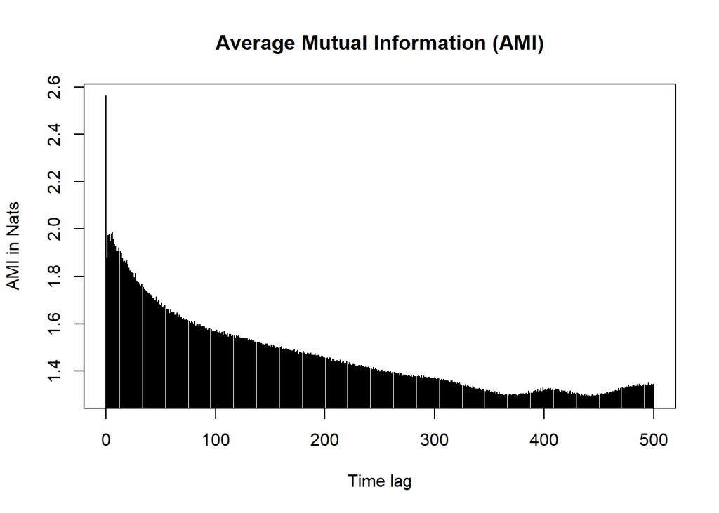

```r
kTimeLag.inf = CalculateTimeLag(hrv.data.inf, technique = "ami", method = "first.minimum",
    lagMax = 500, doPlot = TRUE)
```

```
##  Estimating embedding dimension
```

```
##  Embedding Dimension = 20
```

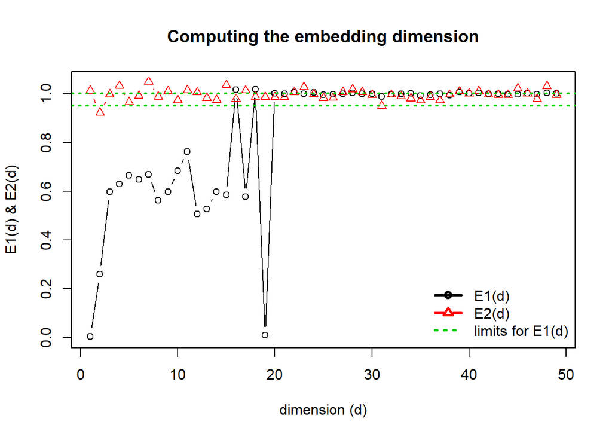

```r
kEmbeddingDim.inf = CalculateEmbeddingDim(hrv.data.inf, numberPoints = 1000,
    timeLag = kTimeLag, maxEmbeddingDim = 50, threshold = 0.95, maxRelativeChange = 0.1,
    doPlot = TRUE)
```

# Correlation Dimension

Some systems with highly complicated dynamics in time also show its complexity in phase space, generating attractors with complicated geometry: the so-called strange attractors. These attractors are often fractal sets, and they are generated by chaotic systems; i.e., systems that despite being completely deterministic are unpredictable in the long term. This has led researchers to try to characterize the dynamical system by measuring the fractal dimension of its attractor. The fractal dimension is a generalization of the Euclidean dimension (they coincide in nonfractal sets) that measures the auto-similarity of the fractal. There are several techniques that approximate the concept of fractal dimension: the box-counting dimension, the information dimension, the correlation dimension, the Renyi dimension and the Higuchi dimension. It should be noted that these fractal dimensions are not equivalent to each other. The correlation dimension is the most common measure in the context of dynamical systems . The estimation of the correlation dimension requires the computation of the so- called correlation sum C(r). The correlation sum is defined over the N points from the phase space as follows:

$$C(r) = \frac{2}{N(N-1)}\sum^N_{i=1}\sum^N_{j=i+1} \Theta (r-||xi-xj||_\infty),$$

where $\Theta$ is the Heaviside step function (which is 0 for negative arguments and 1 for positive arguments), and r is a radius in the phase space. The summation just counts the pairs of points (xi,xj) whose distance in the phase space is smaller than r. Usually, the $L_\infty$ norm is selected in practical implementations; this norm computes the distance between two points as the maximum of the absolute value of the differences between the coordinates of the points. In the remainder of the discussion, distances and neighborhoods should be understood under the $L_\infty$ metric.

The correlation sum is an estimator of the mean probability of two states (at different times) being close. This estimator is biased when the pairs in the sum are not statistically independent, usually because there is some temporal correlation between the Takens’ vectors. This issue is usually solved by using the so-called Theiler window: Two Takens’ vectors must be separated by, at least, the time steps specified by this window in order to be considered neighbors. By using a Theiler window, I exclude temporally correlated vectors from our estimations.

Fractal attractors are expected to fulfil:
$$C(r) \alpha r^D,$$
being D the correlation dimension. Thus, the correlation dimension, similar to the estimation of the Hurst exponent, can be estimated using a log-log regression of C(r) on r. The correlation dimension of a fractal attractor is an invariant of the dynamical system. Thus, it should not depend on the dimension of the Takens’ vectors employed to estimate it (provided that I am using an embedding dimension large enough to reconstruct the phase space). In practical applications, researchers often plot log(C(r)) versus log(r) using several embedding dimensions. To obtain a reliable estimation of the correlation dimension, there must exist a range of r over which log(C(r)) is linear in log(r) for all embedding dimensions larger than some mmin, being mmin the minimum embedding dimension that permits proper phase space reconstruction.

# Generalized Correlation Dimension

As I have previously stated, the correlation sum C(r) can be interpreted as the mean probability of finding a neighbor in a ball of radius r surrounding a point in the phase space: $C(r) = (p(r)) $. The average operation is necessary since the number of points in a neighborhood of a fractal attractor is not homogeneous. Furthermore, the average time that the system spends in a region of the phase space is not homogeneous either. The Renyi dimension (or generalized dimension) takes into account the frequency with which the different regions are visited. The strength of the weighting is controlled by a numeric value q > 0 (the larger the q, the stronger the importance of the most visited regions). After fixing a nmin Theiler window, the generalized correlation dimension is defined:

$$Cq(r)= \frac{1}{(N-2n_{min})(N-2n_{min}-1)} \sum^{N-n_{min}}_{i=n_{min}}[\sum^N_{|j-i|<n_{min}}\Theta(r?-||xi-xj||_\infty)]^{q-1}$$

,which is an estimation of $ (p(r)^{(q-1)}) $. For small radius, it is assumed that $ (p(r)^{(q-1)}) $ $\propto$ $ r^{(q-1)D{q}}) $ , which defines the generalized dimension of order q. An estimation of the generalized dimension of order q is then obtained by fitting a log-log regression of Cq(r) on $r^{(q-1)}$.

# Correlation Dimension

```
##  Computing the Correlation sum
```

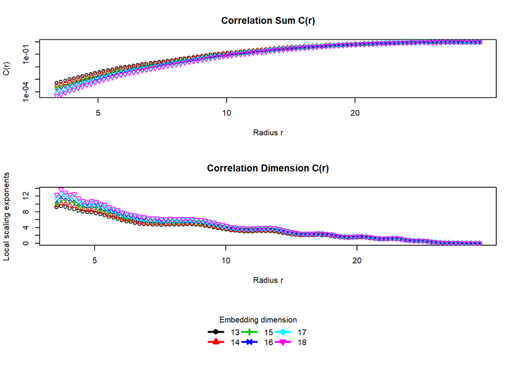

```r
#In a new nonlinear analysis we calculate the correlation dimension
hrv.data.dn = CalculateCorrDim(hrv.data.dn, indexNonLinearAnalysis = 2,
                         minEmbeddingDim = kEmbeddingDim,
                         maxEmbeddingDim = kEmbeddingDim + 5,
                         timeLag = kTimeLag, minRadius = 4, maxRadius = range.pre,
                         pointsRadius = 100,
                         theilerWindow = 200, doPlot = TRUE)
```

```
##  Computing the Correlation sum
```

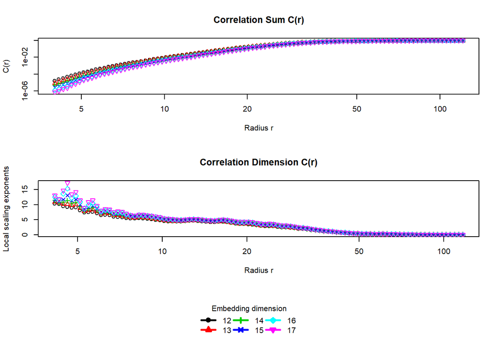

```r
hrv.data.dn.HI = CalculateCorrDim(hrv.data.dn.HI, indexNonLinearAnalysis = 2,
                         minEmbeddingDim = kEmbeddingDim.HI,
                         maxEmbeddingDim = kEmbeddingDim.HI + 5,
                         timeLag = kTimeLag.HI, minRadius = 4, maxRadius = range.HI,
                         pointsRadius = 100,
                         theilerWindow = 200, doPlot = TRUE)
```

```
##  Computing the Correlation sum
```

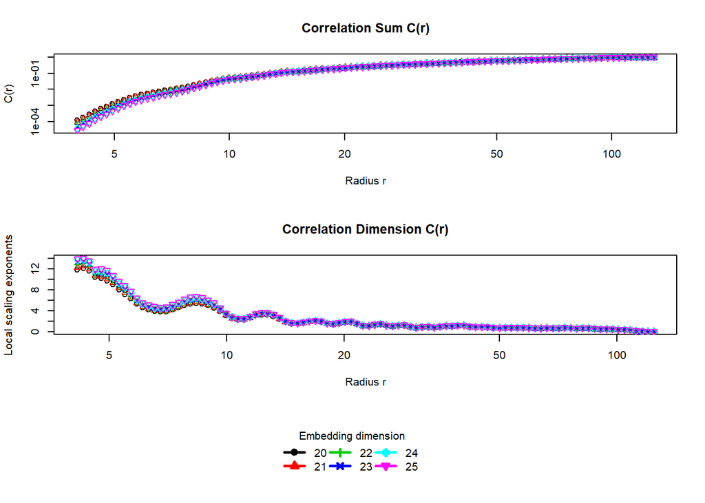

```r
hrv.data.dn.inf = CalculateCorrDim(hrv.data.dn.inf, indexNonLinearAnalysis = 2,
                         minEmbeddingDim = kEmbeddingDim.inf,
                         maxEmbeddingDim = kEmbeddingDim.inf + 5,
                         timeLag = kTimeLag, minRadius = 4, maxRadius = range.inf,
                         pointsRadius = 100,
                         theilerWindow = 200, doPlot = TRUE)
```